# Analyse intégrée Méthylome-Transcriptome

Polypes colorectaux : approche multi-omique

DU Next Generation Sequencing - Université Paris Cité

2026-10-05

# 1 Ressources et support

## 1.1 📚 Documentation

- **R Markdown** : https://rmarkdown.rstudio.com/
- **tidyverse** : https://www.tidyverse.org/
- **Bioconductor** : https://www.bioconductor.org/
- **limma User’s Guide** : https://bioconductor.org/packages/release/bioc/vignettes/limma/inst/doc/usersguide.pdf
- **ComplexHeatmap** : https://jokergoo.github.io/ComplexHeatmap-reference/book/

## 1.2 💾 Instructions de reproduction

Pour reproduire cette analyse :

1. **Télécharger le fichier `.Rmd`** (bouton “Code” en haut à droite de ce document)
2. **Préparer l’arborescence** :
   - Créer un dossier `DATA/` contenant tous les fichiers de données
   - Les dossiers `FIGURES/` et `RESULTS/` seront créés automatiquement
3. **Modifier le chemin du répertoire de travail** (ligne 17 du fichier .Rmd)
4. **Exécuter l’analyse** :
   - Option 1 : Cliquer sur “Knit” pour générer le rapport HTML complet
   - Option 2 : Exécuter chunk par chunk pour une exploration interactive

**Prérequis techniques :**

- R version ≥ 4.0.0
- RStudio (recommandé)
- Connexion Internet (pour installation packages et requêtes BioMart)
- Mémoire RAM ≥ 8 Go (recommandé pour manipulation de grandes matrices)

## 1.3 🆘 Dépannage

**Problèmes fréquents et solutions :**

| Problème | Solution |
| --- | --- |
| Erreur d’installation de packages | Vérifier la connexion Internet, mettre à jour R/RStudio |
| “Fichier non trouvé” | Vérifier le chemin du répertoire de travail et la présence des fichiers dans `DATA/` |
| Erreur BioMart | Réessayer plus tard (serveur parfois surchargé) ou utiliser un miroir alternatif |
| Mémoire insuffisante | Fermer applications non nécessaires, augmenter RAM disponible pour R |

**Pour obtenir de l’aide :** - Lire attentivement les messages d’erreur (souvent en rouge dans la console) - Vérifier la section “Vérification de l’intégrité des fichiers” - Consulter les documentations officielles des packages - Contacter les organisateurs du DU pour support technique

# 2 Contexte et objectifs

**Objectif du TP**

Ce travail pratique propose une analyse intégrée des profils épigénétiques et transcriptomiques de polypes colorectaux. L’approche multi-omique permet d’identifier les mécanismes de régulation génique impliqués dans la transformation tumorale précoce.

**Démarche scientifique :**

- Caractérisation du phénotype méthylateur (signature CIMP)
- Analyse de la méthylation du promoteur de *MLH1*
- Profilage transcriptomique différentiel (Normal vs Polype)
- Corrélation épigénome-transcriptome

**Cohorte :** 7 échantillons (2 normaux, 5 polypes)  
**Technologies :** Illumina EPIC (méthylation), RNA-seq (expression)

# 3 Configuration de l’environnement

## 3.1 Définition du répertoire de travail

```r
# Création de l'arborescence
dir.create("DATA", showWarnings = FALSE)
dir.create("FIGURES", showWarnings = FALSE)
dir.create("RESULTS", showWarnings = FALSE)

cat("✓ Répertoire de travail :", getwd(), "\n")
```

```
## ✓ Répertoire de travail : /home/antoine-qb-pasmant/Bureau/ANTOINE_THESE/PASMANT_ANTOINE/DU_2026_NGS_R_PROGRAM/POLYPES
```

```r
cat("✓ Arborescence créée : DATA/, FIGURES/, RESULTS/\n")
```

```
## ✓ Arborescence créée : DATA/, FIGURES/, RESULTS/
```

**Organisation des données :**  
`DATA/` contient les fichiers bruts • `FIGURES/` accueille les visualisations • `RESULTS/` stocke les analyses tabulaires

## 3.2 Installation et chargement des packages

```r
# Fonction utilitaire pour installer/charger les packages
load_package <- function(pkg) {
  if (!require(pkg, character.only = TRUE, quietly = TRUE)) {
    install.packages(pkg, dependencies = TRUE, repos = "https://cran.r-project.org")
    library(pkg, character.only = TRUE)
  }
}

# Packages CRAN
cran_packages <- c("tidyverse", "data.table", "ggplot2", "ggrepel",
                   "ggpubr", "pheatmap", "reshape2", "patchwork", "scales")
invisible(sapply(cran_packages, load_package))

# Packages Bioconductor
if (!requireNamespace("BiocManager", quietly = TRUE)) {
  install.packages("BiocManager", repos = "https://cran.r-project.org")
}

bioc_packages <- c("ComplexHeatmap", "circlize", "biomaRt", "limma")
for (pkg in bioc_packages) {
  if (!require(pkg, character.only = TRUE, quietly = TRUE)) {
    BiocManager::install(pkg, ask = FALSE, update = FALSE)
    library(pkg, character.only = TRUE)
  }
}

cat("✓ Environnement R configuré avec succès\n")
```

```
## ✓ Environnement R configuré avec succès
```

# 4 Importation des données

## 4.1 Vérification de l’intégrité des fichiers

```r
fichiers_requis <- c(
  "manifest_COMBINED_EPICv2_priority_EPICv1_fallback.csv",
  "CIMP_meth_signature.csv",
  "FinalReport_selected_columns_with_gene_info.txt",
  "Correspondance_Prlvement_ID.csv",
  "CG_MLH1_with_annotations.txt",
  "tablecounts_tpm_polypes.csv",
  "tablecounts_raw_polypes.csv",
  "metadata_RNAseq.csv"
)

statut_fichiers <- sapply(fichiers_requis, function(f) {
  file.exists(file.path("DATA", f))
})

if (all(statut_fichiers)) {
  cat("✓ Tous les fichiers requis sont présents\n")
} else {
  cat("✗ Fichiers manquants :\n")
  print(fichiers_requis[!statut_fichiers])
  stop("Veuillez placer tous les fichiers requis dans le dossier DATA/")
}
```

```
## ✓ Tous les fichiers requis sont présents
```

## 4.2 Chargement des données de méthylation

```r
# Manifeste Illumina EPIC combiné (EPICv1 + EPICv2)
manifeste <- fread("DATA/manifest_COMBINED_EPICv2_priority_EPICv1_fallback.csv", sep = ",") %>%
  rename(chromosome = CHR, Start_hg38 = MAPINFO)

# Signature CIMP (78 CpG discriminants)
signature_CIMP <- read.csv("DATA/CIMP_meth_signature.csv", sep = ";")

# Matrice de β-values (échantillons × sondes)
donnees_meth <- read.delim("DATA/FinalReport_selected_columns_with_gene_info.txt", sep = "\t")
colnames(donnees_meth) <- c("IlmnID", "P1", "P2", "P3", "P4", "P5", "P6", "P7",
                             "UCSC_REFGENE_NAME", "UCSC_REFGENE_GROUPE")

# Métadonnées cliniques
annotations <- read.csv("DATA/Correspondance_Prlvement_ID.csv", skip = 1, sep = ";")

# Sondes ciblant MLH1
cpg_MLH1 <- read.delim("DATA/CG_MLH1_with_annotations.txt", sep = "\t")
colnames(cpg_MLH1) <- c("IlmnID", "UCSC_REFGENE_NAME", "UCSC_REFGENE_GROUPE",
                        "P1", "P2", "P3", "P4", "P5", "P6", "P7")

cat(sprintf("✓ Données de méthylation importées
  • Manifeste : %d sondes (EPICv1 + EPICv2)
  • Matrice de méthylation : %d sondes × %d échantillons
  • Signature CIMP : %d CpG
  • Sondes MLH1 : %d\n",
  nrow(manifeste),
  nrow(donnees_meth),
  ncol(donnees_meth) - 2,
  nrow(signature_CIMP),
  nrow(cpg_MLH1)))
```

```
## ✓ Données de méthylation importées
##   • Manifeste : 1066283 sondes (EPICv1 + EPICv2)
##   • Matrice de méthylation : 865918 sondes × 8 échantillons
##   • Signature CIMP : 89 CpG
##   • Sondes MLH1 : 90
```

## 4.3 Chargement des données de transcriptome

```r
# Expression normalisée (TPM)
transcriptome_tpm <- read.csv("DATA/tablecounts_tpm_polypes.csv", row.names = 1)
colnames(transcriptome_tpm) <- c("P1", "P2", "P3", "P4", "P5", "P6", "P7")

# Comptages bruts
transcriptome_raw <- read.csv("DATA/tablecounts_raw_polypes.csv", row.names = 1)
colnames(transcriptome_raw) <- c("P1", "P2", "P3", "P4", "P5", "P6", "P7")

# Métadonnées RNA-seq
metadata <- read.csv("DATA/metadata_RNAseq.csv", sep = ";")

cat(sprintf("✓ Données de transcriptome importées
  • Expression TPM : %d gènes × %d échantillons
  • Comptages bruts : %d gènes × %d échantillons\n",
  nrow(transcriptome_tpm), ncol(transcriptome_tpm),
  nrow(transcriptome_raw), ncol(transcriptome_raw)))
```

```
## ✓ Données de transcriptome importées
##   • Expression TPM : 57820 gènes × 7 échantillons
##   • Comptages bruts : 57820 gènes × 7 échantillons
```

# 5 Analyse de la signature CIMP

## 5.1 Préparation de la matrice CIMP

```r
# Fusion signature CIMP avec annotations génomiques
signature_complete <- merge(signature_CIMP, manifeste, by = "IlmnID")

# Extraction des β-values pour les 78 CpG de la signature
donnees_CIMP <- merge(donnees_meth, signature_complete, by = "IlmnID") %>%
  dplyr::select(IlmnID, P1:P7, UCSC_REFGENE_NAME, UCSC_REFGENE_GROUPE)

cat("✓ Signature CIMP préparée :", nrow(donnees_CIMP), "CpG retenus\n")
```

```
## ✓ Signature CIMP préparée : 78 CpG retenus
```

## 5.2 Heatmap stratifiée de la signature CIMP

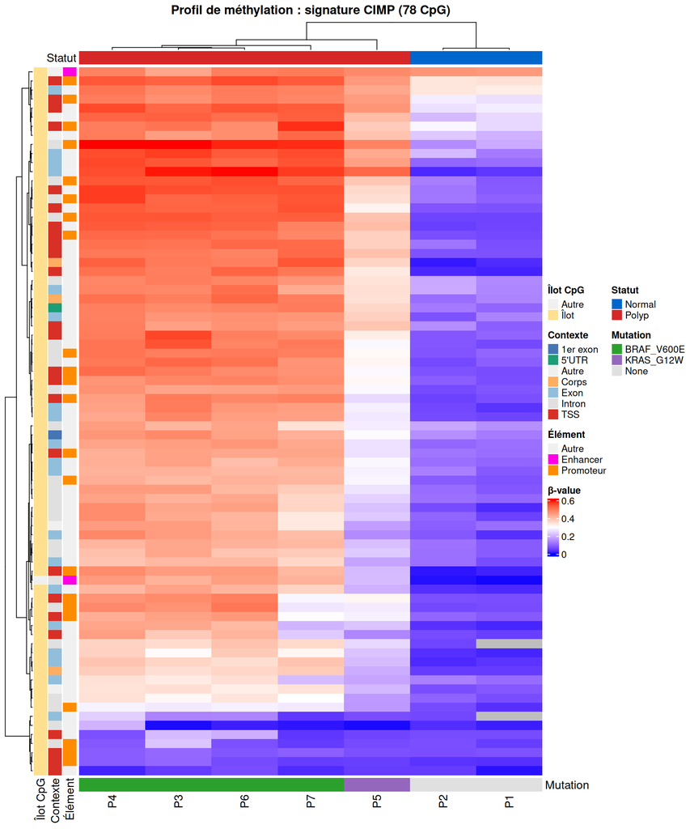

```r
# Préparation de la matrice de β-values
matrice_beta <- as.matrix(donnees_CIMP %>% dplyr::select(P1:P7))
rownames(matrice_beta) <- donnees_CIMP$IlmnID

# Annotations des échantillons (colonnes)
anno_col <- annotations %>%
  dplyr::select(ID, Status, Mutation) %>%
  filter(ID %in% colnames(matrice_beta)) %>%
  as.data.frame()
rownames(anno_col) <- anno_col$ID
anno_col <- anno_col[colnames(matrice_beta), ]

# Annotations des CpG (lignes)
anno_cpg <- donnees_CIMP %>%
  dplyr::select(IlmnID) %>%
  left_join(
    manifeste %>% dplyr::select(IlmnID, Relation_to_UCSC_CpG_Island,
                                 DB_Element_Type, GENCODEv47_Feature_Exon_Number),
    by = "IlmnID"
  ) %>%
  mutate(
    CpG_Island = case_when(
      Relation_to_UCSC_CpG_Island == "Island" ~ "Îlot",
      Relation_to_UCSC_CpG_Island == "Shore" ~ "Rivage",
      Relation_to_UCSC_CpG_Island == "Shelf" ~ "Plateau",
      TRUE ~ "Autre"
    ),
    Contexte = case_when(
      GENCODEv47_Feature_Exon_Number == "TSS" ~ "TSS",
      GENCODEv47_Feature_Exon_Number == "1stExon" ~ "1er exon",
      GENCODEv47_Feature_Exon_Number == "5'UTR" ~ "5'UTR",
      GENCODEv47_Feature_Exon_Number == "3'UTR" ~ "3'UTR",
      GENCODEv47_Feature_Exon_Number == "Body" ~ "Corps",
      GENCODEv47_Feature_Exon_Number == "intron" ~ "Intron",
      str_starts(GENCODEv47_Feature_Exon_Number, "exon") ~ "Exon",
      TRUE ~ "Autre"
    ),
    Element_Reg = case_when(
      DB_Element_Type == "Promoter_2000bp" ~ "Promoteur",
      DB_Element_Type == "Enhancer_5000bp" ~ "Enhancer",
      TRUE ~ "Autre"
    )
  ) %>%
  as.data.frame()
rownames(anno_cpg) <- anno_cpg$IlmnID
anno_cpg <- anno_cpg[rownames(matrice_beta), ]

# Palettes de couleurs
couleurs_statut <- c(Normal = "#0066cc", Polyp = "#d62728")
couleurs_mutation <- c(BRAF_V600E = "#2ca02c", KRAS_G12W = "#9467bd", None = "#e0e0e0")
couleurs_island <- c(Îlot = "#fee090", Rivage = "#fc8d59", Plateau = "#fee090", Autre = "#f0f0f0")
couleurs_contexte <- c(
  TSS = "#d73027", `1er exon` = "#4575b4", `5'UTR` = "#1b9e77", `3'UTR` = "#66c2a5",
  Exon = "#91bfdb", Intron = "#e0e0e0", Corps = "#fdae61", Autre = "#f0f0f0"
)
couleurs_element <- c(Promoteur = "#FF8C00", Enhancer = "#FF00E4", Autre = "#f0f0f0")

# Construction des annotations pour la heatmap
ha_top <- HeatmapAnnotation(
  Statut = anno_col$Status,
  col = list(Statut = couleurs_statut),
  border = FALSE,
  annotation_name_side = "left"
)

ha_bottom <- HeatmapAnnotation(
  Mutation = anno_col$Mutation,
  col = list(Mutation = couleurs_mutation),
  border = FALSE
)

ha_row <- rowAnnotation(
  `Îlot CpG` = anno_cpg$CpG_Island,
  Contexte = anno_cpg$Contexte,
  `Élément` = anno_cpg$Element_Reg,
  col = list(
    `Îlot CpG` = couleurs_island,
    Contexte = couleurs_contexte,
    `Élément` = couleurs_element
  ),
  border = FALSE,
  show_legend = TRUE
)

# Palette de couleurs pour les valeurs beta
col_fun <- colorRamp2(c(0, 0.3, 0.6), c("blue", "white", "red"))

# Création de la heatmap
hm <- Heatmap(
  matrice_beta,
  name = "β-value",
  col = col_fun,
  clustering_method_rows = "ward.D2",
  clustering_method_columns = "ward.D2",
  top_annotation = ha_top,
  bottom_annotation = ha_bottom,
  left_annotation = ha_row,
  show_row_names = FALSE,
  show_column_names = TRUE,
  column_title = "Profil de méthylation : signature CIMP (78 CpG)",
  column_title_gp = gpar(fontsize = 13, fontface = "bold"),
  heatmap_legend_param = list(
    title = "β-value",
    at = seq(0, 0.6, 0.2),
    legend_direction = "vertical"
  )
)

draw(hm)
```

```r
# Sauvegarde
pdf("FIGURES/Heatmap_Signature_CIMP.pdf", width = 10, height = 12)
draw(hm)
dev.off()
```

```r
cat("✓ Heatmap CIMP générée : FIGURES/Heatmap_Signature_CIMP.pdf\n")
```

```
## ✓ Heatmap CIMP générée : FIGURES/Heatmap_Signature_CIMP.pdf
```

**Interprétation :** Le clustering hiérarchique permet d’identifier les groupes d’échantillons partageant des profils de méthylation similaires. Une ségrégation claire entre tissus normaux et polypes suggère un remodelage épigénétique coordonné dans les lésions pré-néoplasiques, caractéristique du phénotype CIMP.

# 6 Analyse du promoteur de *MLH1*

**Contexte biologique :** *MLH1* (*MutL Homolog 1*) est un gène suppresseur de tumeur impliqué dans le système de réparation des mésappariements (MMR). L’hyperméthylation de son promoteur entraîne une perte d’expression, conduisant à une instabilité microsatellitaire (MSI) et à l’accumulation de mutations. Ce mécanisme épigénétique est observé dans ~15% des cancers colorectaux sporadiques.

## 6.1 Préparation et annotation des données MLH1

```r
# Fusion avec le manifeste pour annotations complètes
cpg_MLH1_annote <- cpg_MLH1 %>%
  left_join(
    manifeste %>% dplyr::select(IlmnID, GENCODEv47_Feature_Exon_Number,
                                 Relation_to_UCSC_CpG_Island, DB_Element_Type),
    by = "IlmnID"
  ) %>%
  mutate(
    Contexte = case_when(
      GENCODEv47_Feature_Exon_Number == "TSS" ~ "TSS",
      GENCODEv47_Feature_Exon_Number == "1stExon" ~ "1er exon",
      GENCODEv47_Feature_Exon_Number == "5'UTR" ~ "5'UTR",
      GENCODEv47_Feature_Exon_Number == "3'UTR" ~ "3'UTR",
      GENCODEv47_Feature_Exon_Number == "Body" ~ "Corps",
      GENCODEv47_Feature_Exon_Number == "intron" ~ "Intron",
      str_starts(GENCODEv47_Feature_Exon_Number, "exon") ~ "Exon",
      TRUE ~ "Autre"
    ),
    CpG_Island = case_when(
      Relation_to_UCSC_CpG_Island == "Island" ~ "Îlot",
      Relation_to_UCSC_CpG_Island == "Shore" ~ "Rivage",
      Relation_to_UCSC_CpG_Island == "Shelf" ~ "Plateau",
      TRUE ~ "Autre"
    )
  )

# Transformation en format long pour analyse
donnees_mlh1 <- cpg_MLH1_annote %>%
  pivot_longer(cols = starts_with("P"), names_to = "Echantillon", values_to = "Bvalue") %>%
  left_join(annotations, by = c("Echantillon" = "ID")) %>%
  filter(Contexte %in% c("TSS", "1er exon", "5'UTR", "3'UTR", "Exon", "Intron", "Corps"))

# Ordonnancement des contextes (5' → 3')
donnees_mlh1$Contexte <- factor(
  donnees_mlh1$Contexte,
  levels = c("TSS", "5'UTR", "1er exon", "Exon", "Intron", "Corps", "3'UTR")
)

cat(sprintf("✓ Sondes MLH1 analysées : %d
  Distribution par contexte génomique :\n", n_distinct(cpg_MLH1$IlmnID)))
```

```
## ✓ Sondes MLH1 analysées : 55
##   Distribution par contexte génomique :
```

```r
print(table(cpg_MLH1_annote$Contexte))
```

```
##
##  5'UTR   Exon Intron    TSS
##      2      3     20     65
```

## 6.2 Distribution des β-values par contexte génomique

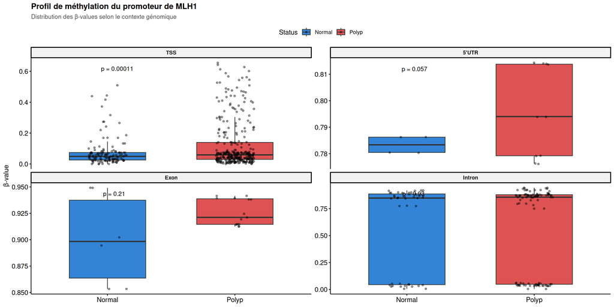

```r
p_mlh1 <- ggplot(donnees_mlh1, aes(x = Status, y = Bvalue, fill = Status)) +
  geom_boxplot(alpha = 0.8, outlier.shape = NA, width = 0.6) +
  geom_jitter(width = 0.15, size = 1.2, alpha = 0.4) +
  facet_wrap(~ Contexte, nrow = 2, scales = "free_y") +
  stat_compare_means(
    method = "t.test",
    label = "p.format",
    size = 3.5,
    label.y.npc = 0.92
  ) +
  scale_fill_manual(values = c("Normal" = "#0066cc", "Polyp" = "#d62728")) +
  labs(
    title = "Profil de méthylation du promoteur de MLH1",
    subtitle = "Distribution des β-values selon le contexte génomique",
    y = "β-value",
    x = NULL
  ) +
  theme_pubr(base_size = 11) +
  theme(
    plot.title = element_text(face = "bold", size = 13),
    plot.subtitle = element_text(size = 10, color = "gray30"),
    legend.position = "top",
    strip.text = element_text(face = "bold")
  )

print(p_mlh1)
```

```r
ggsave("FIGURES/MLH1_Distribution_Contextes.png", plot = p_mlh1,
       width = 14, height = 7, dpi = 300)

cat("✓ Graphique généré : FIGURES/MLH1_Distribution_Contextes.png\n")
```

```
## ✓ Graphique généré : FIGURES/MLH1_Distribution_Contextes.png
```

## 6.3 Profil positionnel le long du gène MLH1

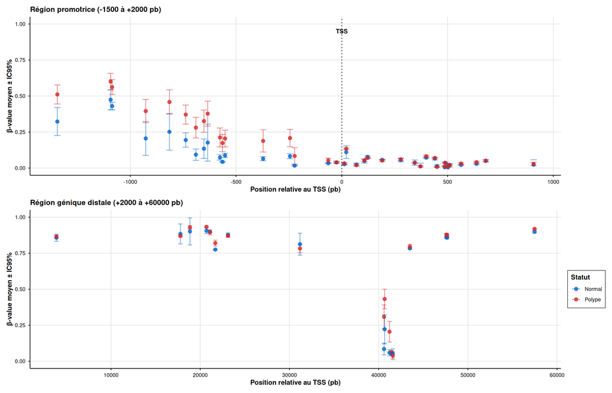

```r
# Fusion avec coordonnées génomiques
cpg_position <- merge(
  cpg_MLH1 %>% distinct(IlmnID, .keep_all = TRUE),
  manifeste,
  by = "IlmnID"
)

# Calcul de la position relative au TSS
tss_position <- min(cpg_position$Start_hg38, na.rm = TRUE)
cpg_position <- cpg_position %>%
  mutate(Position_Relative = Start_hg38 - tss_position - 1345) %>%
  dplyr::select(IlmnID, P1:P7, Position_Relative)

# Format long avec annotations de statut
donnees_pos <- cpg_position %>%
  pivot_longer(
    cols = P1:P7,
    names_to = "Echantillon",
    values_to = "Bvalue"
  ) %>%
  mutate(Statut = ifelse(Echantillon %in% c("P1", "P2"), "Normal", "Polype"))

# Calcul des statistiques par position
stats_position <- donnees_pos %>%
  group_by(Position_Relative, Statut) %>%
  summarise(
    Moyenne = mean(Bvalue, na.rm = TRUE),
    SD = sd(Bvalue, na.rm = TRUE),
    N = n(),
    .groups = 'drop'
  ) %>%
  mutate(
    SE = SD / sqrt(N),
    IC95_inf = Moyenne - 1.96 * SE,
    IC95_sup = Moyenne + 1.96 * SE
  )

# Graphique région promotrice (-1500 à +2000 pb)
p_proximal <- ggplot(
  filter(stats_position, Position_Relative <= 2000),
  aes(x = Position_Relative, y = Moyenne, color = Statut)
) +
  geom_errorbar(
    aes(ymin = IC95_inf, ymax = IC95_sup),
    width = 30,
    alpha = 0.6,
    size = 0.5
  ) +
  geom_point(size = 2.5, alpha = 0.8) +
  geom_vline(xintercept = 0, linetype = "dotted", color = "black", size = 0.6) +
  annotate("text", x = 0, y = 0.95, label = "TSS", size = 3.5, fontface = "bold") +
  scale_color_manual(values = c("Normal" = "#0066cc", "Polype" = "#d62728")) +
  ylim(0, 1) +
  labs(
    title = "Région promotrice (-1500 à +2000 pb)",
    x = "Position relative au TSS (pb)",
    y = "β-value moyen ± IC95%"
  ) +
  theme_minimal(base_size = 11) +
  theme(
    legend.position = "none",
    plot.title = element_text(face = "bold", size = 12),
    axis.line = element_line(color = "black", size = 0.5),
    axis.ticks = element_line(color = "black"),
    axis.text = element_text(color = "black"),
    axis.title = element_text(color = "black", face = "bold"),
    panel.grid.major = element_line(color = "gray90"),
    panel.grid.minor = element_blank()
  )

# Graphique région distale (+2000 à +60000 pb)
p_distal <- ggplot(
  filter(stats_position, Position_Relative > 2000),
  aes(x = Position_Relative, y = Moyenne, color = Statut)
) +
  geom_errorbar(
    aes(ymin = IC95_inf, ymax = IC95_sup),
    width = 500,
    alpha = 0.6,
    size = 0.5
  ) +
  geom_point(size = 2.5, alpha = 0.8) +
  scale_color_manual(
    values = c("Normal" = "#0066cc", "Polype" = "#d62728"),
    name = "Statut"
  ) +
  ylim(0, 1) +
  labs(
    title = "Région génique distale (+2000 à +60000 pb)",
    x = "Position relative au TSS (pb)",
    y = "β-value moyen ± IC95%"
  ) +
  theme_minimal(base_size = 11) +
  theme(
    plot.title = element_text(face = "bold", size = 12),
    axis.line = element_line(color = "black", size = 0.5),
    axis.ticks = element_line(color = "black"),
    axis.text = element_text(color = "black"),
    axis.title = element_text(color = "black", face = "bold"),
    panel.grid.major = element_line(color = "gray90"),
    panel.grid.minor = element_blank(),
    legend.position = "right",
    legend.title = element_text(face = "bold"),
    legend.background = element_rect(fill = "white", color = "black", size = 0.3)
  )

# Assemblage des graphiques
p_combine <- p_proximal / p_distal
print(p_combine)
```

```r
ggsave("FIGURES/MLH1_Profil_Positionnel.png", plot = p_combine,
       width = 14, height = 9, dpi = 300, bg = "white")

cat("✓ Graphique généré : FIGURES/MLH1_Profil_Positionnel.png\n")
```

```
## ✓ Graphique généré : FIGURES/MLH1_Profil_Positionnel.png
```

# 7 Analyse différentielle du transcriptome

**Méthodologie :** L’analyse différentielle repose sur le package `limma`, utilisant des modèles linéaires avec modération bayésienne des variances. Cette approche robuste est particulièrement adaptée aux cohortes de taille modérée. L’analyse est réalisée sur les données TPM (Transcripts Per Million) après transformation log2.

## 7.1 Chargement et préparation des données

```r
# Chargement des données TPM et raw counts
transcriptome_tpm <- read.csv("DATA/tablecounts_tpm_polypes.csv", row.names = 1)
colnames(transcriptome_tpm) <- c("P1", "P2", "P3", "P4", "P5", "P6", "P7")
transcriptome_tpm <- transcriptome_tpm[, !(names(transcriptome_tpm) %in% "P5")]

transcriptome_raw <- read.csv("DATA/tablecounts_raw_polypes.csv", row.names = 1)
colnames(transcriptome_raw) <- c("P1", "P2", "P3", "P4", "P5", "P6", "P7")
transcriptome_raw <- transcriptome_raw[, !(names(transcriptome_raw) %in% "P5")]
transcriptome_raw_name <- transcriptome_raw

# Chargement des métadonnées
metaData <- read.csv("DATA/metadata_RNAseq.csv", sep = ";")
metaData <- metaData[!grepl("P5", metaData$id), ]

# Définition du design expérimental
group <- factor(metaData$status, levels = c("Normal", "Polyp"))
design <- model.matrix(~ group)

cat(sprintf("✓ Données transcriptomiques chargées
  • TPM : %d gènes × %d échantillons
  • Design : Normal (n = %d), Polyp (n = %d)\n",
  nrow(transcriptome_tpm), ncol(transcriptome_tpm),
  sum(group == "Normal"), sum(group == "Polyp")))
```

```
## ✓ Données transcriptomiques chargées
##   • TPM : 57820 gènes × 6 échantillons
##   • Design : Normal (n = 2), Polyp (n = 4)
```

## 7.2 Analyse différentielle avec limma

```r
# Transformation logarithmique des TPM
log2TPM <- log2(transcriptome_tpm)

# Ajustement du modèle linéaire
fit <- limma::lmFit(log2TPM, design)
fit <- limma::eBayes(fit)

# Extraction des résultats
results_limma <- limma::topTable(fit, coef = "groupPolyp", number = Inf, sort.by = "none")

cat(sprintf("✓ Analyse différentielle limma complétée
  • Gènes testés : %d\n", nrow(results_limma)))
```

```
## ✓ Analyse différentielle limma complétée
##   • Gènes testés : 57820
```

## 7.3 Annotation avec BioMart

```r
## Annotation avec BioMart ------------------------------------------------------

# Fonction pour retirer les versions Ensembl éventuelles :
# ENSG00000141510.18 -> ENSG00000141510
clean_ensembl_id <- function(x) {
  sub("\\..*$", "", x)
}

# IDs Ensembl à annoter
ensembl_ids <- unique(clean_ensembl_id(rownames(results_limma)))

cat(sprintf(
  "Annotation de %d identifiants Ensembl...\n",
  length(ensembl_ids)
))
```

```
## Annotation de 57820 identifiants Ensembl...
```

```r
# -------------------------------------------------------------------------
# 1. Tentatives successives sur plusieurs serveurs Ensembl
# -------------------------------------------------------------------------

ensembl_hosts <- c(
  "https://www.ensembl.org",
  "https://useast.ensembl.org",
  "https://asia.ensembl.org"
)

gene_symbols <- NULL
successful_host <- NULL

for (host in ensembl_hosts) {

  cat(sprintf("→ Tentative BioMart : %s\n", host))

  gene_symbols_try <- tryCatch({

    mart <- biomaRt::useMart(
      biomart = "ENSEMBL_MART_ENSEMBL",
      dataset = "hsapiens_gene_ensembl",
      host = host
    )

    biomaRt::getBM(
      attributes = c(
        "ensembl_gene_id",
        "hgnc_symbol"
      ),
      filters = "ensembl_gene_id",
      values = ensembl_ids,
      mart = mart
    )

  }, error = function(e) {

    cat(sprintf(
      "  ✗ Échec : %s\n",
      conditionMessage(e)
    ))

    NULL
  })

  # Si la requête a fonctionné
  if (!is.null(gene_symbols_try) &&
      nrow(gene_symbols_try) > 0) {

    gene_symbols <- gene_symbols_try
    successful_host <- host

    cat(sprintf(
      "  ✓ Connexion réussie : %s\n",
      host
    ))

    break
  }
}
```

```
## → Tentative BioMart : https://www.ensembl.org
##   ✗ Échec : Unable to contact any Ensembl mirror
## → Tentative BioMart : https://useast.ensembl.org
##   ✗ Échec : HTTP 403 Forbidden.
## → Tentative BioMart : https://asia.ensembl.org
##   ✗ Échec : HTTP 403 Forbidden.
```

```r
# -------------------------------------------------------------------------
# 2. Backup local avec org.Hs.eg.db si BioMart est indisponible
# -------------------------------------------------------------------------

if (is.null(gene_symbols)) {

  cat("\n⚠ Tous les serveurs BioMart sont indisponibles.\n")
  cat("→ Tentative d'annotation locale avec org.Hs.eg.db...\n")

  if (requireNamespace("org.Hs.eg.db", quietly = TRUE) &&
      requireNamespace("AnnotationDbi", quietly = TRUE)) {

    hgnc_symbols <- AnnotationDbi::mapIds(
      org.Hs.eg.db::org.Hs.eg.db,
      keys = ensembl_ids,
      keytype = "ENSEMBL",
      column = "SYMBOL",
      multiVals = "first"
    )

    gene_symbols <- data.frame(
      ensembl_gene_id = names(hgnc_symbols),
      hgnc_symbol = unname(hgnc_symbols),
      stringsAsFactors = FALSE
    )

    successful_host <- "org.Hs.eg.db (annotation locale)"

    cat("✓ Annotation locale réalisée avec org.Hs.eg.db\n")

  } else {

    stop(
      paste0(
        "\nImpossible d'annoter les gènes.\n\n",
        "BioMart est inaccessible et le package org.Hs.eg.db ",
        "n'est pas installé.\n\n",
        "Installe-le avec :\n",
        "BiocManager::install('org.Hs.eg.db')"
      )
    )
  }
}
```

```
##
## ⚠ Tous les serveurs BioMart sont indisponibles.
## → Tentative d'annotation locale avec org.Hs.eg.db...
```

```
## ✓ Annotation locale réalisée avec org.Hs.eg.db
```

```r
# -------------------------------------------------------------------------
# 3. Nettoyage de l'annotation
# -------------------------------------------------------------------------

# Certains symboles peuvent être vides
gene_symbols$hgnc_symbol[
  gene_symbols$hgnc_symbol == ""
] <- NA

# Sécurité : un seul résultat par Ensembl ID
gene_symbols <- gene_symbols[
  !duplicated(gene_symbols$ensembl_gene_id),
]

cat(sprintf(
  "\n✓ Annotation terminée\n  • Source : %s\n  • %d / %d gènes avec symbole HGNC (%.1f%%)\n",
  successful_host,
  sum(!is.na(gene_symbols$hgnc_symbol)),
  length(ensembl_ids),
  100 * sum(!is.na(gene_symbols$hgnc_symbol)) / length(ensembl_ids)
))
```

```
##
## ✓ Annotation terminée
##   • Source : org.Hs.eg.db (annotation locale)
##   • 34190 / 57820 gènes avec symbole HGNC (59.1%)
```

```r
# -------------------------------------------------------------------------
# 4. Ajout des symboles HGNC aux TPM
# -------------------------------------------------------------------------

transcriptome_tpm_name <- transcriptome_tpm

transcriptome_tpm_name$ensembl_gene_id <-
  clean_ensembl_id(rownames(transcriptome_tpm_name))

# Utilisation de match() plutôt que merge()
# -> conserve exactement l'ordre original des gènes
transcriptome_tpm_name$hgnc_symbol <-
  gene_symbols$hgnc_symbol[
    match(
      transcriptome_tpm_name$ensembl_gene_id,
      gene_symbols$ensembl_gene_id
    )
  ]

# -------------------------------------------------------------------------
# 5. Ajout des symboles HGNC aux raw counts
# -------------------------------------------------------------------------

transcriptome_raw_name <- transcriptome_raw

transcriptome_raw_name$ensembl_gene_id <-
  clean_ensembl_id(rownames(transcriptome_raw_name))

transcriptome_raw_name$hgnc_symbol <-
  gene_symbols$hgnc_symbol[
    match(
      transcriptome_raw_name$ensembl_gene_id,
      gene_symbols$ensembl_gene_id
    )
  ]

# -------------------------------------------------------------------------
# 6. Ajout des symboles HGNC aux résultats limma
# -------------------------------------------------------------------------

results_limma_name <- results_limma

results_limma_name$ensembl_gene_id <-
  clean_ensembl_id(rownames(results_limma_name))

results_limma_name$hgnc_symbol <-
  gene_symbols$hgnc_symbol[
    match(
      results_limma_name$ensembl_gene_id,
      gene_symbols$ensembl_gene_id
    )
  ]

# -------------------------------------------------------------------------
# 7. Résumé final
# -------------------------------------------------------------------------

n_annotated <- sum(
  !is.na(results_limma_name$hgnc_symbol) &
    results_limma_name$hgnc_symbol != ""
)

cat(sprintf(
  "\n✓ Annotation ajoutée aux données\n  • TPM : %d gènes\n  • Raw counts : %d gènes\n  • Limma : %d gènes\n  • Symboles HGNC retrouvés : %d / %d (%.1f%%)\n",
  nrow(transcriptome_tpm_name),
  nrow(transcriptome_raw_name),
  nrow(results_limma_name),
  n_annotated,
  nrow(results_limma_name),
  100 * n_annotated / nrow(results_limma_name)
))
```

```
##
## ✓ Annotation ajoutée aux données
##   • TPM : 57820 gènes
##   • Raw counts : 57820 gènes
##   • Limma : 57820 gènes
##   • Symboles HGNC retrouvés : 34190 / 57820 (59.1%)
```

## 7.4 Nettoyage et filtrage des résultats

```r
# Filtrage des gènes sans symbole
final_transcriptome <- results_limma_name %>%
  dplyr::filter(!is.na(hgnc_symbol), hgnc_symbol != "")

# Exclusion de gènes spécifiques (si nécessaire)
final_transcriptome <- final_transcriptome %>%
  dplyr::filter(!ensembl_gene_id %in% c("ENSG00000169064", "ENSG00000223839"))

# Nettoyage des valeurs infinies/manquantes et catégorisation
final_transcriptome_clean <- final_transcriptome %>%
  dplyr::filter(!is.na(logFC), !is.na(adj.P.Val), is.finite(logFC), is.finite(adj.P.Val)) %>%
  dplyr::mutate(adj.P.Val = ifelse(adj.P.Val == 0, 1e-300, adj.P.Val))

final_transcriptome_clean$Significance <- with(
  final_transcriptome_clean,
  ifelse(adj.P.Val < 0.05 & logFC > 1, "Up",
         ifelse(adj.P.Val < 0.05 & logFC < -1, "Down", "Not significant"))
)

# Export des résultats
write.csv(final_transcriptome, "RESULTS/final_transcriptome.csv", row.names = FALSE)
write.csv(final_transcriptome_clean, "RESULTS/final_transcriptome_with_significance.csv", row.names = FALSE)

cat(sprintf("✓ Résultats nettoyés et exportés
  • Gènes retenus : %d
  • Sur-exprimés (Up) : %d
  • Sous-exprimés (Down) : %d
  • Non significatifs : %d\n",
  nrow(final_transcriptome_clean),
  sum(final_transcriptome_clean$Significance == "Up"),
  sum(final_transcriptome_clean$Significance == "Down"),
  sum(final_transcriptome_clean$Significance == "Not significant")))
```

```
## ✓ Résultats nettoyés et exportés
##   • Gènes retenus : 17261
##   • Sur-exprimés (Up) : 235
##   • Sous-exprimés (Down) : 36
##   • Non significatifs : 16990
```

## 7.5 Volcano plot

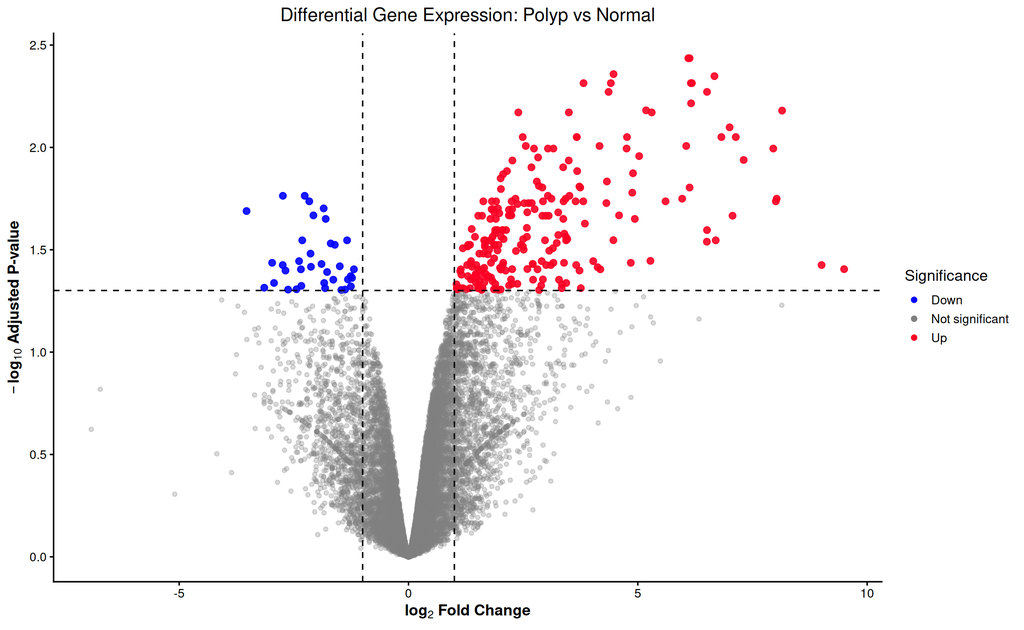

```r
volcano_plot <- ggplot(
  final_transcriptome_clean,
  aes(x = logFC, y = -log10(adj.P.Val), color = Significance)
) +
  geom_point(
    alpha = ifelse(final_transcriptome_clean$Significance == "Up", 0.9,
                   ifelse(final_transcriptome_clean$Significance == "Down", 0.9, 0.3)),
    size = ifelse(final_transcriptome_clean$Significance == "Up", 2.5,
                  ifelse(final_transcriptome_clean$Significance == "Down", 2.5, 1.5))
  ) +
  geom_vline(xintercept = c(-1, 1), linetype = "dashed") +
  geom_hline(yintercept = -log10(0.05), linetype = "dashed") +
  scale_color_manual(values = c("Up" = "#FA0024", "Down" = "blue", "Not significant" = "grey50")) +
  labs(
    title = "Differential Gene Expression: Polyp vs Normal",
    x = expression(bold(log[2]~bold("Fold Change"))),
    y = expression(bold(-log[10]~bold("Adjusted P-value")))
  ) +
  theme_classic(base_size = 14) +
  theme(plot.title = element_text(hjust = 0.5))

print(volcano_plot)
```

```r
ggsave("FIGURES/Volcano_plot_RNASEQ_HighRes.png", plot = volcano_plot,
       width = 13, height = 8, dpi = 300)

cat("✓ Volcano plot généré : FIGURES/Volcano_plot_RNASEQ_HighRes.png\n")
```

```
## ✓ Volcano plot généré : FIGURES/Volcano_plot_RNASEQ_HighRes.png
```

**Interprétation :** Le volcano plot met en évidence les gènes différentiellement exprimés entre tissus normaux et polypes. Les gènes en rouge (“Up”) sont significativement sur-exprimés dans les polypes (logFC > 1, p.adj < 0.05), tandis que les gènes en bleu (“Down”) sont sous-exprimés (logFC < -1, p.adj < 0.05). Les gènes non significatifs apparaissent en gris. Cette visualisation permet d’identifier rapidement les dérégulations transcriptionnelles majeures associées à la transformation pré-néoplasique.

# 8 Intégration multi-omique

**Approche intégrative :** La corrélation entre profils de méthylation et d’expression permet d’identifier les gènes dont la régulation transcriptionnelle est sous contrôle épigénétique. Une anti-corrélation (hyperméthylation → sous-expression) suggère une répression médiée par la méthylation du promoteur.

## 8.1 Calcul des différences de méthylation (promoteurs uniquement)

```r
# Fusion avec le manifeste pour annotations complètes
donnees_meth_annote <- donnees_meth %>%
  left_join(
    manifeste %>% dplyr::select(
      IlmnID,
      GENCODEv47_Feature_Exon_Number,
      DB_Element_Type,
      Relation_to_UCSC_CpG_Island,
      GENCODEv47_Gene_Name
    ),
    by = "IlmnID"
  )

# Filtrage strict : TSS uniquement ET exclusion de "Body" dans UCSC_REFGENE_GROUPE
donnees_clean <- donnees_meth_annote %>%
  dplyr::select(-P5) %>%
  filter(
    GENCODEv47_Feature_Exon_Number == "TSS",
    !str_detect(UCSC_REFGENE_GROUPE, "Body")  # NOUVEAU : exclusion des annotations "Body"
  ) %>%
  filter(!is.na(UCSC_REFGENE_NAME), UCSC_REFGENE_NAME != "")

cat(sprintf("✓ Filtrage des sondes pour delta méthylation
  • Critères appliqués :
    - Annotation GENCODE v47 : TSS uniquement
    - Exclusion : sondes avec 'Body' dans UCSC_REFGENE_GROUPE
  • Sondes retenues : %d\n", nrow(donnees_clean)))
```

```
## ✓ Filtrage des sondes pour delta méthylation
##   • Critères appliqués :
##     - Annotation GENCODE v47 : TSS uniquement
##     - Exclusion : sondes avec 'Body' dans UCSC_REFGENE_GROUPE
##   • Sondes retenues : 163253
```

```r
# Expansion des annotations multi-gènes
donnees_expanded <- donnees_clean %>%
  dplyr::select(IlmnID, UCSC_REFGENE_NAME, P1, P2, P3, P4, P6, P7) %>%
  separate_rows(UCSC_REFGENE_NAME, sep = ";") %>%
  mutate(UCSC_REFGENE_NAME = str_trim(UCSC_REFGENE_NAME)) %>%
  filter(!is.na(UCSC_REFGENE_NAME), UCSC_REFGENE_NAME != "")

# Pivotage en format long
donnees_long <- donnees_expanded %>%
  pivot_longer(
    cols = c(P1, P2, P3, P4, P6, P7),
    names_to = "Echantillon",
    values_to = "Bvalue"
  ) %>%
  left_join(annotations %>% dplyr::select(ID, Status), by = c("Echantillon" = "ID"))

# Agrégation par gène et groupe
moyennes_gene <- donnees_long %>%
  group_by(UCSC_REFGENE_NAME, Status) %>%
  summarise(
    Moyenne = mean(Bvalue, na.rm = TRUE),
    N_sondes = n_distinct(IlmnID),
    N_obs = n(),
    .groups = "drop"
  )

# Calcul du delta (Polype - Normal)
delta_methylation <- moyennes_gene %>%
  pivot_wider(
    names_from = Status,
    values_from = c(Moyenne, N_sondes, N_obs)
  ) %>%
  rename(
    Moy_Normal = Moyenne_Normal,
    Moy_Polype = Moyenne_Polyp,
    N_sondes_Normal = N_sondes_Normal,
    N_sondes_Polype = N_sondes_Polyp
  ) %>%
  filter(!is.na(Moy_Normal), !is.na(Moy_Polype)) %>%
  filter(N_sondes_Normal >= 3, N_sondes_Polype >= 3) %>%  # Au moins 3 sondes par groupe
  mutate(
    N_sondes = pmin(N_sondes_Normal, N_sondes_Polype),
    Delta_Meth = Moy_Polype - Moy_Normal
  ) %>%
  arrange(desc(abs(Delta_Meth)))

# Export
write.csv(delta_methylation, "RESULTS/Delta_Methylation_Genes_Promoteurs.csv", row.names = FALSE)

cat(sprintf("\n✓ Delta méthylation calculé
  • Gènes avec delta calculé : %d
  • Hyperméthylés (Δβ > 0.1) : %d
  • Hypométhylés (Δβ < -0.1) : %d\n\nTop 10 gènes hyperméthylés (promoteur TSS, sans Body) :\n",
  nrow(delta_methylation),
  sum(delta_methylation$Delta_Meth > 0.1),
  sum(delta_methylation$Delta_Meth < -0.1)))
```

```
##
## ✓ Delta méthylation calculé
##   • Gènes avec delta calculé : 19537
##   • Hyperméthylés (Δβ > 0.1) : 1900
##   • Hypométhylés (Δβ < -0.1) : 21
##
## Top 10 gènes hyperméthylés (promoteur TSS, sans Body) :
```

```r
print(head(delta_methylation %>%
           filter(Delta_Meth > 0) %>%
           arrange(desc(Delta_Meth)) %>%
           dplyr::select(UCSC_REFGENE_NAME, Delta_Meth, Moy_Normal, Moy_Polype, N_sondes), 10))
```

```
## # A tibble: 10 × 5
##    UCSC_REFGENE_NAME Delta_Meth Moy_Normal Moy_Polype N_sondes
##    <chr>                  <dbl>      <dbl>      <dbl>    <int>
##  1 MSC                    0.424     0.0819      0.506        3
##  2 BVES                   0.399     0.0735      0.473       10
##  3 BVES-AS1               0.397     0.0719      0.469        4
##  4 FOXE1                  0.395     0.153       0.548        5
##  5 RIMS2                  0.388     0.130       0.518        6
##  6 EPHA7                  0.385     0.125       0.510        6
##  7 C20orf194              0.380     0.0529      0.433       10
##  8 FOXI3                  0.376     0.0877      0.464        5
##  9 CABP7                  0.376     0.122       0.498        4
## 10 GPRASP1                0.373     0.175       0.548       10
```

```r
cat("\nTop 10 gènes hypométhylés (promoteur TSS, sans Body) :\n")
```

```
##
## Top 10 gènes hypométhylés (promoteur TSS, sans Body) :
```

```r
print(head(delta_methylation %>%
           filter(Delta_Meth < 0) %>%
           arrange(Delta_Meth) %>%
           dplyr::select(UCSC_REFGENE_NAME, Delta_Meth, Moy_Normal, Moy_Polype, N_sondes), 10))
```

```
## # A tibble: 10 × 5
##    UCSC_REFGENE_NAME Delta_Meth Moy_Normal Moy_Polype N_sondes
##    <chr>                  <dbl>      <dbl>      <dbl>    <int>
##  1 ZFR                   -0.138      0.719      0.582        5
##  2 LINC01122             -0.136      0.690      0.554        3
##  3 SEMG1                 -0.132      0.480      0.348        3
##  4 EFCAB14-AS1           -0.130      0.642      0.512        3
##  5 GDPD4                 -0.123      0.715      0.591        5
##  6 LOC102546299          -0.116      0.482      0.366        3
##  7 OR5R1                 -0.115      0.630      0.515        3
##  8 FGB                   -0.115      0.641      0.526        3
##  9 GP2                   -0.114      0.679      0.565        7
## 10 STATH                 -0.112      0.760      0.648        5
```

## 8.2 Fusion des données omiques

```r
# Intégration méthylation-expression
donnees_integrees <- merge(
  final_transcriptome_clean,
  delta_methylation %>% dplyr::select(UCSC_REFGENE_NAME, Delta_Meth, N_sondes),
  by.x = "hgnc_symbol",
  by.y = "UCSC_REFGENE_NAME"
)

# Catégorisation par quadrant
donnees_integrees <- donnees_integrees %>%
  mutate(
    Quadrant = case_when(
      Delta_Meth >= 0.1 & logFC >= 1.5 ~ "Hyperméthylé & Sur-exprimé",
      Delta_Meth < -0.1 & logFC >= 1.5 ~ "Hypométhylé & Sur-exprimé",
      Delta_Meth >= 0.1 & logFC < -1.5 ~ "Hyperméthylé & Sous-exprimé",
      Delta_Meth < -0.1 & logFC < -1.5 ~ "Hypométhylé & Sous-exprimé",
      TRUE ~ "Non catégorisé"
    )
  )

cat(sprintf("✓ Intégration multi-omique réalisée
  • Gènes avec données couplées : %d
  • Basé sur : promoteurs TSS uniquement (sans Body)\n",
  nrow(donnees_integrees)))
```

```
## ✓ Intégration multi-omique réalisée
##   • Gènes avec données couplées : 13020
##   • Basé sur : promoteurs TSS uniquement (sans Body)
```

## 8.3 Distribution par quadrant

```r
stats_quadrants <- donnees_integrees %>%
  filter(Quadrant != "Non catégorisé") %>%
  group_by(Quadrant) %>%
  summarise(N = n(), .groups = "drop") %>%
  mutate(
    x_label = case_when(
      str_detect(Quadrant, "Hyperméthylé") ~ 0.25,
      str_detect(Quadrant, "Hypométhylé") ~ -0.25
    ),
    y_label = case_when(
      str_detect(Quadrant, "Sur-exprimé") ~ 5,
      str_detect(Quadrant, "Sous-exprimé") ~ -5
    )
  )

write.csv(stats_quadrants, "RESULTS/Distribution_Quadrants.csv", row.names = FALSE)

cat("\n✓ Distribution des gènes par quadrant :\n")
```

```
##
## ✓ Distribution des gènes par quadrant :
```

```r
print(stats_quadrants %>% dplyr::select(Quadrant, N))
```

```
## # A tibble: 4 × 2
##   Quadrant                        N
##   <chr>                       <int>
## 1 Hyperméthylé & Sous-exprimé    80
## 2 Hyperméthylé & Sur-exprimé     86
## 3 Hypométhylé & Sous-exprimé      1
## 4 Hypométhylé & Sur-exprimé       1
```

## 8.4 Graphique de corrélation épigénome-transcriptome

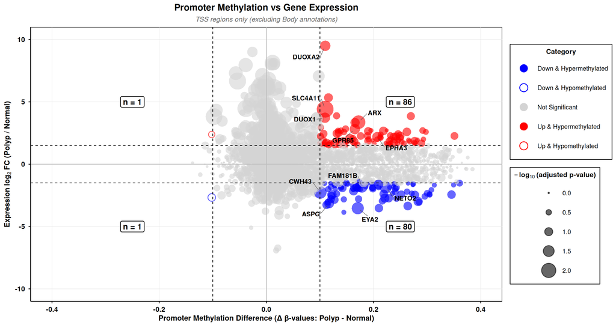

```r
# Sélection des gènes à étiqueter
genes_label <- donnees_integrees %>%
  filter(adj.P.Val < 0.05, abs(Delta_Meth) > 0.1, abs(logFC) > 1.5)

# Recatégorisation pour le graphique
donnees_integrees <- donnees_integrees %>%
  mutate(
    Quadrant_Clean = case_when(
      Delta_Meth >= 0.1 & logFC >= 1.5 ~ "Up & Hypermethylated",
      Delta_Meth < -0.1 & logFC >= 1.5 ~ "Up & Hypomethylated",
      Delta_Meth >= 0.1 & logFC < -1.5 ~ "Down & Hypermethylated",
      Delta_Meth < -0.1 & logFC < -1.5 ~ "Down & Hypomethylated",
      TRUE ~ "Not Significant"
    )
  )

# Construction du graphique
p_correlation <- ggplot(donnees_integrees, aes(x = Delta_Meth, y = logFC)) +
  geom_point(
    aes(color = Quadrant_Clean, shape = Quadrant_Clean, size = -log10(adj.P.Val)),
    alpha = 0.6,
    stroke = 1
  ) +
  scale_size_continuous(
    trans = exp_trans(),
    range = c(0.5, 14),
    name = expression(bold(-log[10]~"(adjusted p-value)")),
    breaks = c(0, 0.5, 1, 1.5, 2),
    labels = c("0.0", "0.5", "1.0", "1.5", "2.0"),
    guide = guide_legend(override.aes = list(size = 8))
  ) +
  scale_color_manual(
    values = c(
      "Up & Hypermethylated" = "red",
      "Up & Hypomethylated" = "red",
      "Down & Hypermethylated" = "blue",
      "Down & Hypomethylated" = "blue",
      "Not Significant" = "lightgray"
    ),
    name = "Category",
    na.value = "lightgray"
  ) +
  scale_shape_manual(
    values = c(
      "Up & Hypermethylated" = 16,
      "Up & Hypomethylated" = 1,
      "Down & Hypermethylated" = 16,
      "Down & Hypomethylated" = 1,
      "Not Significant" = 16
    ),
    name = "Category",
    na.value = 16
  ) +
  geom_hline(yintercept = 0, linetype = "solid", color = "grey", size = 0.6) +
  geom_vline(xintercept = 0, linetype = "solid", color = "grey", size = 0.6) +
  geom_hline(yintercept = c(1.5, -1.5), linetype = "dashed", color = "black", size = 0.5) +
  geom_vline(xintercept = c(0.1, -0.1), linetype = "dashed", color = "black", size = 0.5) +
  xlim(-0.4, 0.4) +
  ylim(-10, 10) +
  labs(
    x = expression(bold("Promoter Methylation Difference (Δ β-values: Polyp - Normal)")),
    y = expression(bold("Expression") ~ bold(log[2]) ~ bold("FC (Polyp / Normal)")),
    title = "Promoter Methylation vs Gene Expression",
    subtitle = "TSS regions only (excluding Body annotations)"
  ) +
  theme_minimal(base_size = 14) +
  theme(
    plot.title = element_text(hjust = 0.5, face = "bold", color = "black", size = 16),
    plot.subtitle = element_text(hjust = 0.5, face = "italic", color = "gray40", size = 12),
    axis.line.x = element_line(color = "black", size = 0.6),
    axis.line.y = element_line(color = "black", size = 0.6),
    axis.ticks = element_line(color = "black"),
    axis.title = element_text(face = "bold", color = "black", size = 13),
    axis.text = element_text(face = "bold", color = "black", size = 12),
    legend.position = "right",
    legend.title = element_text(face = "bold", size = 12, color = "black"),
    legend.text = element_text(size = 11, color = "black"),
    legend.background = element_rect(fill = "white", color = "black", size = 0.5),
    legend.key.size = unit(1.2, "cm"),
    panel.grid.major = element_line(color = "gray90", size = 0.3),
    panel.grid.minor = element_blank(),
    panel.background = element_rect(fill = "white"),
    plot.background = element_rect(fill = "white")
  ) +
  guides(
    color = guide_legend(
      title.position = "top",
      title.hjust = 0.5,
      override.aes = list(alpha = 1, size = 6)
    ),
    shape = guide_legend(
      title.position = "top",
      title.hjust = 0.5,
      override.aes = list(size = 6)
    ),
    size = guide_legend(
      title.position = "top",
      title.hjust = 0.5
    )
  )

# Étiquetage des gènes significatifs
if (nrow(genes_label) > 0) {
  p_correlation <- p_correlation +
    geom_text_repel(
      data = genes_label,
      aes(label = hgnc_symbol),
      size = 4,
      fontface = "bold",
      color = "black",
      max.overlaps = Inf,
      box.padding = 1,
      point.padding = 0.3,
      segment.color = "gray30",
      segment.size = 0.3
    )
}

# Annotations de comptage dans les quadrants
if (nrow(stats_quadrants) > 0) {
  stats_quadrants <- stats_quadrants %>%
    mutate(label_text = paste0("n = ", N))

  p_correlation <- p_correlation +
    geom_label(
      data = stats_quadrants,
      aes(x = x_label, y = y_label, label = label_text),
      color = "black",
      fill = "white",
      size = 5,
      fontface = "bold",
      label.size = 0.5,
      inherit.aes = FALSE
    )
}

print(p_correlation)
```

```r
ggsave("FIGURES/Correlation_Methylome_Transcriptome.png",
       plot = p_correlation, width = 15, height = 8, dpi = 300, bg = "white")

cat("✓ Graphique généré : FIGURES/Correlation_Methylome_Transcriptome.png\n")
```

```
## ✓ Graphique généré : FIGURES/Correlation_Methylome_Transcriptome.png
```

**Interprétation biologique :**

- **Quadrant inférieur droit** (hyperméthylation + sous-expression) : Ce quadrant contient les gènes montrant une répression transcriptionnelle probablement médiée par la méthylation du promoteur. Il s’agit du mécanisme épigénétique classique d’inactivation de gènes suppresseurs de tumeurs.
- **Quadrant supérieur gauche** (hypométhylation + sur-expression) : Ces gènes suggèrent une activation transcriptionnelle associée à une déméthylation du promoteur, mécanisme potentiellement impliqué dans la réactivation d’oncogènes ou de gènes du développement silencieux dans les tissus adultes normaux.
- **Quadrants paradoxaux** : Les gènes montrant une discordance entre méthylation et expression suggèrent des mécanismes de régulation alternatifs (modifications d’histones, facteurs de transcription, microARN, régulation post-transcriptionnelle).

# 9 Synthèse et export des résultats

## 9.1 Statistiques récapitulatives

```r
cat("\n═══════════════════════════════════════════════════════════\n")
```

```
##
## ═══════════════════════════════════════════════════════════
```

```r
cat("                    SYNTHÈSE DES ANALYSES                  \n")
```

```
##                     SYNTHÈSE DES ANALYSES
```

```r
cat("═══════════════════════════════════════════════════════════\n\n")
```

```
## ═══════════════════════════════════════════════════════════
```

```r
cat("MÉTHYLOME :\n")
```

```
## MÉTHYLOME :
```

```r
cat("  • Signature CIMP :", nrow(donnees_CIMP), "CpG analysés\n")
```

```
##   • Signature CIMP : 78 CpG analysés
```

```r
cat("  • Sondes MLH1 :", n_distinct(cpg_MLH1$IlmnID), "CpG\n")
```

```
##   • Sondes MLH1 : 55 CpG
```

```r
cat("  • Gènes avec profil différentiel (promoteurs TSS sans Body) :",
    nrow(delta_methylation), "\n\n")
```

```
##   • Gènes avec profil différentiel (promoteurs TSS sans Body) : 19537
```

```r
cat("TRANSCRIPTOME :\n")
```

```
## TRANSCRIPTOME :
```

```r
cat("  • Gènes analysés :", nrow(final_transcriptome_clean), "\n")
```

```
##   • Gènes analysés : 17261
```

```r
cat("  • Sur-exprimés (Up, logFC > 1, p.adj < 0.05) :",
    sum(final_transcriptome_clean$Significance == "Up"), "\n")
```

```
##   • Sur-exprimés (Up, logFC > 1, p.adj < 0.05) : 235
```

```r
cat("  • Sous-exprimés (Down, logFC < -1, p.adj < 0.05) :",
    sum(final_transcriptome_clean$Significance == "Down"), "\n\n")
```

```
##   • Sous-exprimés (Down, logFC < -1, p.adj < 0.05) : 36
```

```r
cat("INTÉGRATION MULTI-OMIQUE :\n")
```

```
## INTÉGRATION MULTI-OMIQUE :
```

```r
cat("  • Gènes avec données couplées :", nrow(donnees_integrees), "\n")
```

```
##   • Gènes avec données couplées : 13020
```

```r
cat("  • Gènes catégorisés dans quadrants :",
    sum(donnees_integrees$Quadrant != "Non catégorisé"), "\n")
```

```
##   • Gènes catégorisés dans quadrants : 168
```

```r
cat("\n  Distribution par quadrant :\n")
```

```
##
##   Distribution par quadrant :
```

```r
for (i in 1:nrow(stats_quadrants)) {
  cat("    •", stats_quadrants$Quadrant[i], ":", stats_quadrants$N[i], "gènes\n")
}
```

```
##     • Hyperméthylé & Sous-exprimé : 80 gènes
##     • Hyperméthylé & Sur-exprimé : 86 gènes
##     • Hypométhylé & Sous-exprimé : 1 gènes
##     • Hypométhylé & Sur-exprimé : 1 gènes
```

```r
cat("\n═══════════════════════════════════════════════════════════\n")
```

```
##
## ═══════════════════════════════════════════════════════════
```

## 9.2 Inventaire des fichiers générés

```r
cat("\n✓ FICHIERS GÉNÉRÉS\n\nFigures (FIGURES/) :\n")
```

```
##
## ✓ FICHIERS GÉNÉRÉS
##
## Figures (FIGURES/) :
```

```r
fichiers_fig <- list.files("FIGURES", full.names = FALSE)
if (length(fichiers_fig) > 0) {
  walk(fichiers_fig, ~ cat("  •", .x, "\n"))
} else {
  cat("  (aucun fichier)\n")
}
```

```
##   • Correlation_Methylome_Transcriptome.png
##   • Heatmap_Signature_CIMP.pdf
##   • MLH1_Distribution_Contextes.png
##   • MLH1_Profil_Positionnel.png
##   • Volcano_plot_RNASEQ_HighRes.png
```

```r
cat("\nRésultats (RESULTS/) :\n")
```

```
##
## Résultats (RESULTS/) :
```

```r
fichiers_res <- list.files("RESULTS", full.names = FALSE)
if (length(fichiers_res) > 0) {
  walk(fichiers_res, ~ cat("  •", .x, "\n"))
} else {
  cat("  (aucun fichier)\n")
}
```

```
##   • Delta_Methylation_Genes_Promoteurs.csv
##   • Distribution_Quadrants.csv
##   • final_transcriptome_with_significance.csv
##   • final_transcriptome.csv
```

## 9.3 Traçabilité et informations de session

```r
writeLines(capture.output(sessionInfo()), "RESULTS/Session_Info.txt")
cat("\n✓ Informations de session enregistrées : RESULTS/Session_Info.txt
  (Versions des packages R utilisés pour la reproductibilité)\n")
```

```
##
## ✓ Informations de session enregistrées : RESULTS/Session_Info.txt
##   (Versions des packages R utilisés pour la reproductibilité)
```

# 10 Conclusion

Cette analyse intégrée révèle des altérations épigénétiques et transcriptomiques caractéristiques de la transformation pré-néoplasique des polypes colorectaux. Les principaux résultats incluent :

Ces données constituent une base solide pour des analyses approfondies (enrichissement fonctionnel, validation par bisulfite sequencing, études de survie) et s’inscrivent dans une approche de médecine de précision pour la stratification des patients.

**Pour aller plus loin :**

- **Analyses fonctionnelles** : Gene Ontology, KEGG, Reactome pour identifier les voies biologiques dérégulées
- **Validation orthogonale** : qPCR pour l’expression, pyroséquençage bisulfite pour la méthylation
- **Corrélation clinique** : Association avec données de récidive, survie, réponse thérapeutique
- **Extension omique** : Intégration de marques épigénétiques supplémentaires (modifications d’histones, accessibilité chromatinienne par ATAC-seq)
- **Analyses de réseaux** : Identification de modules co-régulés (WGCNA) et de régulateurs maîtres

*Document généré le 2026-10-05*  
*DU Next Generation Sequencing - Université Paris Cité*  
*Module : Analyses Intégrées Multi-Omiques*